# DARE-3

Seulbi Lee, Havi Khurana, Janette Avelar

2024-02-18

### A. Baseline randomization checks

```r
## Table 2. Comparison of Baseline Characteristics for Children in READ 180 Enterprise and Control Group

dat_a1 <- dat |>
  mutate(
    treat = factor(treat, levels=c(0,1), labels = c("Control", "READ 180"))) |>
  rename("Free/Reduced Price Lunch" = frpl, "Female" = female, "Dibels Oral Reading Fluency (DORF)" = dorf) |>
  group_by(treat) |>
  dplyr::summarize(
    across(c("Free/Reduced Price Lunch", Female, "Dibels Oral Reading Fluency (DORF)"),
           list(n = ~n(), m = ~mean(., na.rm = TRUE), sd = ~sd(., na.rm = TRUE)),
           .names = "{.col}.{.fn}")) |>
  pivot_longer(
    cols = -treat,
    names_to = c("Variable",".value"),
    names_pattern = "([^.]+)\\.(n|m|sd)") |>
  pivot_wider(
    names_from = treat,
    values_from = c(n, m, sd),
    names_sep = "_"
  ) |>
  select(Variable,"n_Control","m_Control","sd_Control","n_READ 180","m_READ 180","sd_READ 180") |>
    mutate(across(-Variable, ~round(.x, 3)))

## Add t and p values

frpl <- t.test(frpl ~ treat, dat)
female <- t.test(female ~ treat, dat)
dorf <- t.test(dorf ~ treat, dat)

a1_stats <- data.frame(
  Variable = c("Free/Reduced Price Lunch", 'Female', 'Dibels Oral Reading Fluency (DORF)'),
  t = map_dbl(list(frpl, female, dorf), ~round(.x$statistic,3)),
  p = map_dbl(list(frpl, female, dorf), ~round(.x$p.value,3))
)

dat_a1 <- left_join(dat_a1, a1_stats, by = "Variable")

nice_table <- function(data, separate.header = TRUE) {
  if(separate.header) {
    kable(data, "html") |>
      kable_styling(bootstrap_options = c("striped", "hover"), full_width = F) |>
      add_header_above(c(" " = 1, "Control" = 3, "READ 180" = 3))
  } else {
    kable(data, "html") |>
      kable_styling(bootstrap_options = c("striped", "hover"), full_width = F)
  }
}

new_table <- function(data, separate.header = TRUE) {
  if(separate.header) {
    kable(data, "html") |>
      kable_styling(bootstrap_options = c("striped", "hover"), full_width = F) |>
      add_header_above(c(" " = 1, "Control" = 3, "READ 180" = 3, " " = 2))
  } else {
    kable(data, "html") |>
      kable_styling(bootstrap_options = c("striped", "hover"), full_width = F)
  }
}

names(dat_a1)[-1] <- paste0(
  paste0(c("n", "M", "SD","n", "M", "SD","t","p"))
)

new_table(dat_a1, separate.header = TRUE)
```

| Variable | Control n | Control M | Control SD | READ 180 n | READ 180 M | READ 180 SD | t | p |
| --- | --- | --- | --- | --- | --- | --- | --- | --- |
| Free/Reduced Price Lunch | 157 | 0.707 | 0.457 | 155 | 0.671 | 0.471 | 0.686 | 0.493 |
| Female | 157 | 0.561 | 0.498 | 155 | 0.523 | 0.501 | 0.671 | 0.503 |
| Dibels Oral Reading Fluency (DORF) | 157 | 86.245 | 25.936 | 155 | 87.121 | 30.117 | -0.275 | 0.783 |

**A1.**

The comparison between treatment and control groups at baseline showed no statistically significant difference in baseline characteristics for the full sample as p-values for all variables are not lower than 0.05 and t-values are relatively low, indicating there are no significant differences between the two groups.

### B. Replication and Extension

```r
#models
ols1 <- lm(sat10_compreh ~ read180_attend,
           data = dat)
ols2 <- lm(sat10_compreh ~ read180_attend + as.factor(frpl) + as.factor(female) + dorf,
           data = dat)
ols3 <- feols(sat10_compreh ~ read180_attend + as.factor(frpl) + as.factor(female) + dorf | school,
              data = dat)
# ols4 <- lm(sat10_compreh ~ read180_attend + as.factor(frpl) + as.factor(female) + dorf + as.factor(school),
#            data = dat)
#fixed effects row
row <- tribble(~term,          ~'1',  ~'2', ~'3',
                 'School Fixed Effects', 'No', 'No', 'Yes')
attr(row, 'position') <- c(9)
#table
modelsummary(list(
  "Model 1" = ols1,
  "Model 2" = ols2,
  "Model 3" = ols3),
  title = "Table 1. OLS Estimates of Attendance Rate in READ180 Intervention",
  stars = TRUE,
  coef_map = c(
    "(Intercept)" = "Intercept",
    "read180_attend" = "Attendance proportion",
    "as.factor(frpl)1" = "Free/Reduced Price lunch",
    "as.factor(female)1" = "Female",
    "dorf" = "DIBELS Oral Reading Fluency score",
    "frpl" = "Free and reduced-price lunch eligible"
  ),
  gof_omit = "AIC|BIC|Log|F|RMSE|Std.Errors|R2 .*",
  add_rows = row,
  type = "html")
```

Table 1. OLS Estimates of Attendance Rate in READ180 Intervention

|  | Model 1 | Model 2 | Model 3 |
| --- | --- | --- | --- |
| Intercept | 624.692*** | 542.259*** |  |
|  | (2.505) | (3.997) |  |
| Attendance proportion | 11.111* | 9.662*** | 9.672* |
|  | (4.326) | (2.261) | (1.828) |
| Free/Reduced Price lunch |  | −4.307* | −4.019 |
|  |  | (2.106) | (4.011) |
| Female |  | 1.183 | 1.102 |
|  |  | (1.945) | (1.482) |
| School Fixed Effects | No | No | Yes |
| DIBELS Oral Reading Fluency score |  | 0.984*** | 0.985*** |
|  |  | (0.035) | (0.049) |
| Num.Obs. | 312 | 312 | 312 |
| R2 | 0.021 | 0.736 | 0.740 |

+ p < 0.1, * p < 0.05, ** p < 0.01, *** p < 0.001

```r
  #coef_omit = "(Intercept)")
```

**B1.** Our results from the naive OLS models show that higher attendance in the READ 180 program improves post-test reading scores on the final reading comprehension assessment. In the unconditional model, we estimated that attending 100% of the READ180 program sessions increases the score on the SAT10 comprehension test by 11 points (p < 0.05), on average among low-performing upper-elementary students. In model 2, we added student-level baseline covariates which reduced our intercept and the estimated magnitude of attendance on overall final performance slightly, but made the estimate more precise. In model 3, we added school-level fixed effects to account for clustering and school-level variation. In this model, we estimated that attending 100% of the READ180 program sessions increased the post-test score by 9.6 points (p < 0.05). However, none of these results should be interpreted as the causal effect of READ 180 on reading comprehension outcomes. Although treatment was randomly assigned, attendance is an endogenous predictor and there may be differences in groups of students with high and low attendance.

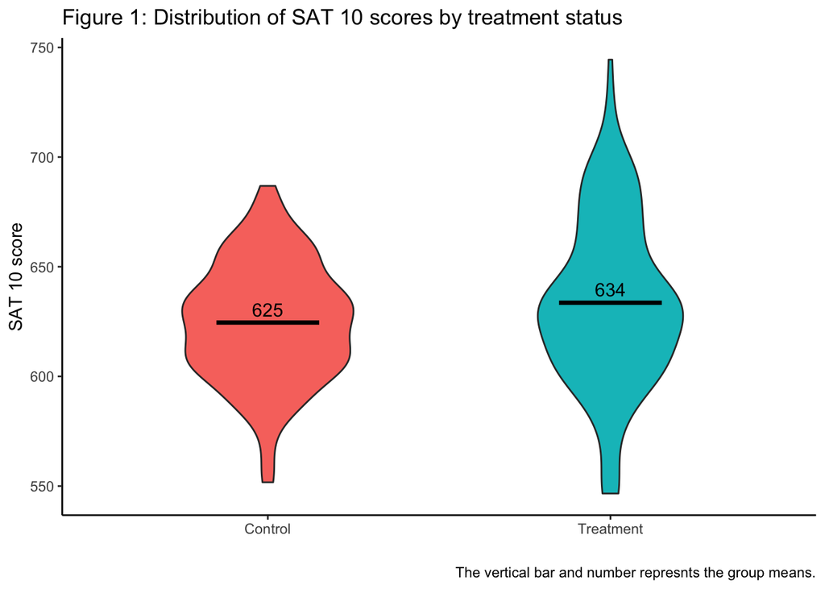

```r
ggplot(dat, aes(x =  as.factor(treat), y = sat10_compreh, fill = as.factor(treat)))+
  geom_violin(show.legend = FALSE,
              width = 0.5)+
  stat_summary(fun = "mean",
               geom = "crossbar",
               width = 0.3,show.legend = FALSE) +
  stat_summary(geom="text", fun.y="mean",
               aes(label=sprintf("%1.0f", ..y..)),
               position=position_nudge(y = 6), size=4)+
  labs(x = "",
       y = "SAT 10 score",
       title = "Figure 1: Distribution of SAT 10 scores by treatment status",
       caption = "The vertical bar and number represnts the group means.") +
  scale_x_discrete(labels = c("Control", "Treatment")) +
  theme_classic()
```

**B2.**

```r
## Intent-to-Treat (ITT) estimates
# mutate to factor
itt1 <- feols(sat10_compreh ~ treat, data=dat)
itt2 <- feols(sat10_compreh ~ treat + frpl + female + dorf, data=dat)
itt3 <- feols(sat10_compreh ~ treat + frpl + female + dorf | school, data=dat)

## Create a row indicating FEs
row <- tribble(~term,          ~'1',  ~'2', ~'3',
                 'School Fixed Effects', 'No', 'No', 'Yes')
attr(row, 'position') <- c(9)

modelsummary(list("Model1" = itt1, "Model 2" = itt2, "Model 3" = itt3),
               title = "Table 3. Intent-to-Treat Estimates of Being Assigned to Participate in an After-school READ180 Intervention.",
               stars=c('*' = 0.05, '**' = 0.01, '***' = 0.001),
               coef_omit = "(Intercept)|as.factor",
               coef_rename = c("treat" = "Assignment","frpl" = "Free/Reduced Price Lunch", "female" = "Female", "dorf" = "DORF"),
               estimate = "{estimate}{stars}",
               gof_omit= "Adj|Pseudo|Log|Within|AIC|BIC|Std|F",
               add_rows = row,
               threeparttable= T,
              vcov = "robust",
               notes = c("Notes: The table displays coefficients from Equation X and robust standard errors in parentheses."),
               type='html')
```

Table 3. Intent-to-Treat Estimates of Being Assigned to Participate in an After-school READ180 Intervention.

|  | Model1 | Model 2 | Model 3 |
| --- | --- | --- | --- |
| Assignment | 9.014* | 8.037*** | 8.003* |
|  | (3.711) | (1.936) | (1.938) |
| Free/Reduced Price Lunch |  | −4.553* | −4.243 |
|  |  | (2.176) | (2.153) |
| Female |  | 1.328 | 1.232 |
|  |  | (1.949) | (1.958) |
| DORF |  | 0.985*** | 0.985*** |
|  |  | (0.039) | (0.039) |
| School Fixed Effects | No | No | Yes |
| Num.Obs. | 312 | 312 | 312 |
| R2 | 0.019 | 0.736 | 0.739 |
| RMSE | 32.60 | 16.92 | 16.82 |

Notes: The table displays coefficients from Equation X and robust standard errors in parentheses.

**B3.**

```r
# TOT

# Only instrument, no covariates
tot1 <- feols(sat10_compreh ~ 1 | read180_attend ~ factor(treat), dat)
# Add covariates
tot2 <- feols(sat10_compreh ~  factor(frpl) + factor(female) + dorf | read180_attend ~ factor(treat), dat)
# Add school fixed effects
tot3 <- feols(sat10_compreh ~ factor(frpl) + factor(female) + dorf | school | read180_attend ~ factor(treat), dat)

modelsummary(list("Model 1" = tot1, "Model 2" = tot2,"Model 3" = tot3),
               title = "Table 3. Treatment on the Treated Estimates of Attending an After-school READ180 Intervention.",
             vcov = "robust",
               stars=c('*' = 0.05, '**' = 0.01, '***' = 0.001),
               coef_omit = "(Intercept)|as.factor",
               coef_rename = c("fit_read180_attend" = "Predicted READ180 Attendace","factor(frpl)1" = "Free/Reduced Price Lunch", "factor(female)1" = "Female", "dorf" = "DORF"),
               estimate = "{estimate}{stars}",
               gof_omit= "Adj|Pseudo|Log|Within|AIC|BIC|Std|F",
               add_rows = row,
               threeparttable= T,
               notes = c("Notes: The table displays coefficients from Equation X and robust standard errors in parentheses."),
               type='html')
```

Table 3. Treatment on the Treated Estimates of Attending an After-school READ180 Intervention.

|  | Model 1 | Model 2 | Model 3 |
| --- | --- | --- | --- |
| Predicted READ180 Attendace | 11.472* | 10.236*** | 10.208* |
|  | (4.719) | (2.461) | (2.469) |
| Free/Reduced Price Lunch |  | −4.273 | −3.992 |
|  |  | (2.176) | (2.154) |
| Female |  | 1.192 | 1.114 |
|  |  | (1.950) | (1.958) |
| DORF |  | 0.984*** | 0.985*** |
|  |  | (0.039) | (0.039) |
| School Fixed Effects | No | No | Yes |
| Num.Obs. | 312 | 312 | 312 |
| R2 | 0.021 | 0.736 | 0.740 |
| RMSE | 32.57 | 16.90 | 16.79 |

Notes: The table displays coefficients from Equation X and robust standard errors in parentheses.

**B5.** In our replication study, we found that implementation of the READ 180 after-school program improved reading comprehension on the SAT 10 assessment. In our first set of models, our ITT estimates indicated that assignment to the READ 180 program increased reading comprehension scores by 9 points. Our TOT estimate, implemented by IV strategy, was higher that the ITT estimate, attending 100% of the READ 180 sessions increased test scores by 10 points. Together, our ITT and TOT analyses indicate that the READ 180 intervention had a positive effect on the comprehension skills of at-risk upper-elementary students. Our findings are robust across baseline student characteristics and school fixed effects. These findings are in line with the original randomized control trial results presented by Kim and colleagues (2011). As a replication study, we are subject to the same sampling and generalizability limitations of the original study, including that we were unable to examine whether differences in prior levels of achievement may influence the results we found and cannot speak to the longitudinal effects or generalizability to wider populations of students that are not lower-performing 4th and 5th grade readers. Further, it’s important to note that our data did not include student racial characteristics, grade level information, or outcomes for spelling and vocabulary, thus our estimates may show some differences from those in the original study.